# 뉴스 정보 크롤링 및 분석

최근 트렌드를 알기위해 뉴스 정보를 크롤링하여 분석해볼것임.

2024년 12월 03일 00시 ~ 2024년 12월 09일 23시 59분 59초까지의 뉴스정보를 수집하여,

일자별로 가장 많이 언급된 키워드 TOP 10 을 추출하여 최근 뜨거운 감자가 무엇인지 알아보겠음.

## 타겟 플랫폼

- [KBS 뉴스]
  - [사회면](https://news.kbs.co.kr/news/pc/category/category.do?ctcd=0005&ref=pSiteMap#20241209&1)

## 크롤링 과정 요약

### 1. 뉴스 목록 수집

[figure not shown]

페이지네이션 방식으로 뉴스 목록을 내어주고있음.

페이지네이션을 위한 API가 존재할 것이기 때문에, 네트워크 탭을 여러 API 정보를 찾아봄.

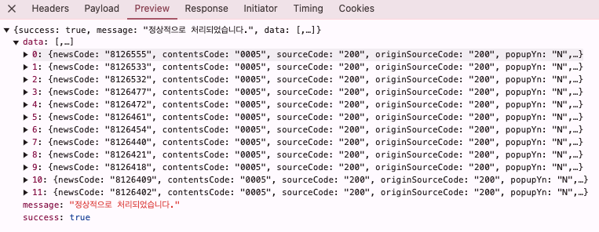

응답정보 확인

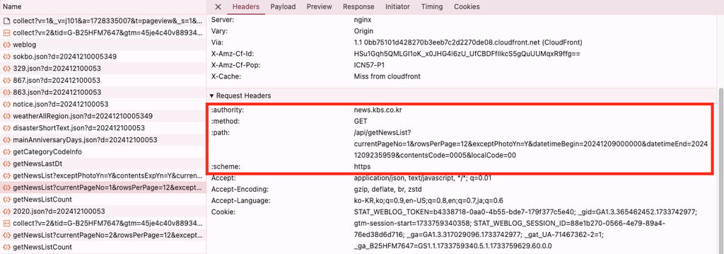

요청 헤더와 파라미터 정보 확인.

### 2. 뉴스 상세정보 수집

[figure not shown]

뉴스목록을 받아오는 API에서 얻은 `newsCode`를 `ncd` 파라미터로 넘겨주면 뉴스 상세정보를 받아올 수 있음.

#### 2-1. 뉴스 상세정보 수집

이후엔 requests, aiohttp 등의 클라이언트를 사용하여 html 정보를 수집하고 beautifulsoup 으로 파싱하여 필요한 데이터를 추출함.

### 3. 데이터 저장 (선택)

코드 작성과정 및 결과 부검을 위해 데이터를 저장해둘 필요가 있다고 생각함.

jsonl, csv 등의 형태로 저장할 것이고, 필요에따라 재사용할 수 있음

#### 3-1. 뉴스정보 형태

[output not shown]

저장하게된다면 위와 같은 형태로 뉴스 정보를 저장할 것인데, jsonl에 저장할 경우 한줄에 하나의 뉴스정보가 들어가게 됨.

### 4. 분석

kiwi 형태소 분석기를 사용하여 뉴스 제목을 형태소 분석하여 가장 많이 언급된 키워드를 추출할 것임.

뉴스 컨텐츠에는 너무 많은 텍스트가 포함되어있고 불필요한 정보가 많기 때문에 제목을 기준으로 고유명사만 추출할 것임.

#### 4-1 데이터 저장

```
jsonl
{"date": "2024-12-03", "title_count": {"검찰": 12, "총장": 1, "긴급": 3, "간부": 4, ...}}
{"date": "2024-12-04", "title_count": {"탄핵": 6, "소추": 2, "안": 3, "쟁점": 2, "법조": 5, "비상계엄": 26, ...}}
{"date": "2024-12-05", "title_count": {"거리": 2, "광장": 3, "확산": 2, "대통령": 35, ...}}
...
```

위와 같은 형식으로 일자별 뉴스에서 등장한 키워드를 저장할 것임.

# 뉴스정보 수집

- 한번에 많은 양의 뉴스를 수집할 것이기 때문에 비동기 방식으로 처리할 것
  - aiohttp를 사용하여 비동기로 뉴스 정보를 수집할 것
- 수집한 데이터는 jsonl 형태로 저장할 것

```python
import asyncio
from datetime import datetime
import json
import os
import pathlib
from aiohttp import (
    ClientSession,
    ClientTimeout,
)
from bs4 import BeautifulSoup
from fake_useragent import UserAgent

BASE_PATH = os.path.dirname(os.path.abspath('')) # 현재 파일의 경로
DATA_PATH = os.path.join(BASE_PATH, "data") # 데이터 저장 경로
NEWS_CONTENT_PATH = f"{DATA_PATH}/kbs/news/content.jsonl" # 뉴스 컨텐츠 저장 경로
CLIENT_REQUEST_TIMEOUT = 10 # HTTP 요청 제한 시간, 너무 오래 걸리는 요청은 무시
DATETIME_BEGIN = datetime(2024, 12, 3, 0, 0, 0)  # 2024-12-03 00:00:00
DATETIME_END = datetime(2024, 12, 9, 23, 59, 59)  # 2024-12-09 23:59:59

KBS_NEWS_SOCITY_CATEGORY_CODE = "0005" # 사회면
KBS_NEWS_LIST_URL = "https://news.kbs.co.kr/api/getNewsList" # 뉴스 목록 요청 URL
KBS_NEWS_VIEW_URL = "https://news.kbs.co.kr/news/view.do" # 뉴스 본문 요청 URL

def ensure_path(path: str):
    """
    경로가 존재하지 않으면 생성
    """
    pathlib.Path(path).mkdir(parents=True, exist_ok=True)
    return path

async def fetch(
    session,
    url,
    params: dict | None = None,
    headers: dict | None = None,
) -> bytes:
    """
    HTTP GET 요청을 보내고 응답을 받아온 뒤 바이트로 반환
    """
    if not params:
        params = {}
    if not headers:
        headers = {}

    async with session.get(
        url,
        params=params,
        headers=headers,
    ) as response:
        return await response.read()

async def fetch_news_ids(
    session,
    begin: datetime,
    end: datetime,
    queue: asyncio.Queue,
) -> None:
    """
    KBS 뉴스 목록을 요청하고 뉴스 ID를 큐에 추가
    """
    contents_code = KBS_NEWS_SOCITY_CATEGORY_CODE
    page_no = 1

    while True:
        params = {
            "currentPageNo": page_no, # 페이지 번호
            "rowsPerPage": 100, # 한 페이지에 100개의 뉴스 요청
            "exceptPhotoYn": "Y", # 사진 뉴스 제외
            "datetimeBegin": begin.strftime("%Y%m%d%H%M%S"), # 시작 일시
            "datetimeEnd": end.strftime("%Y%m%d%H%M%S"), # 종료 일시
            "contentsCode": contents_code, # 뉴스 카테고리 코드
            "localCode": "00", # 뭔지 모르지만, 사이트에서 00으로 고정
        }
        headers = {
            # NOTE: 차단을 피하기 위해 User-Agent를 랜덤하게 설정
            # 이 외에 User-Agent를 설정하지 않으면 403 Forbidden 에러 발생할 수 있음
            "User-Agent": UserAgent().random,
            "Content-Type": "application/json",
        }
        bytes_ = await fetch(
            session=session,
            url=KBS_NEWS_LIST_URL,
            params=params,
            headers=headers,
        )
        print(f"page_no: {page_no:2d},", end=" ")
        try:
            data = json.loads(bytes_)
            if not data.get("success") or not data.get("data"):
                print("no data")
                break
            print(f"news count: {len(data['data']):4d}")
            for metadata in data["data"]:
                news_id = metadata.get("newsCode")
                if not news_id:
                    continue
                await queue.put(news_id)
        except json.JSONDecodeError:
            raise Exception(f"Failed to decode json: {bytes_}")
        page_no += 1

async def _parse_news_content(
    session,
    news_id: str,
) -> dict | None:
    """
    KBS 뉴스 본문을 요청하고 뉴스 제목, 내용, 작성일시를 반환
    """
    params = {"ncd": news_id}
    headers = {
        "User-Agent": UserAgent().random,
        "Content-Type": "text/html; charset=UTF-8",
    }
    bytes_ = await fetch(
        session=session,
        url=KBS_NEWS_VIEW_URL,
        params=params,
        headers=headers,
    )
    soup = BeautifulSoup(bytes_, "html.parser")
    content_text_element = soup.find("div", {"id": "cont_newstext"})
    created_at_element = soup.find("p", {"class": "input-date"})
    title_element = soup.find("meta", {"name": "title"})

    if not content_text_element:
        print(f"news_id: {news_id}, no cont_newstext")
        content_text = None
    else:
        content_text = content_text_element.get_text().strip()
    if not title_element:
        print(f"news_id: {news_id}, no title")
        title_text = None
    else:
        title_text = title_element.get("content").strip() # type: ignore
    if not created_at_element:
        created_at_element = soup.find("em", {"class": "input-date"})
    if not created_at_element:
        created_at = None
    else:
        created_at = datetime.strptime(
            created_at_element.get_text().strip(),
            "입력 %Y.%m.%d (%H:%M)",
        ).strftime("%Y-%m-%d %H:%M:%S")

    return {
        'id': news_id,
        'title': title_text,
        'content': content_text,
        'created_at': created_at,
    }
```

```python
async def parse_kbs_news_ids(kbs_news_id_queue: asyncio.Queue):
    """
    KBS 뉴스 ID 큐에 수집한 뉴스 ID 추가
    """
    ensure_path(f"{DATA_PATH}/kbs/news")
    datetime_begin = DATETIME_BEGIN
    datetime_end = DATETIME_END

    async with ClientSession(
        timeout=ClientTimeout(CLIENT_REQUEST_TIMEOUT),
    ) as session:
        await fetch_news_ids(
            session=session,
            begin=datetime_begin,
            end=datetime_end,
            queue=kbs_news_id_queue,
        )

async def parse_news_content(
    news_id_queue: asyncio.Queue,
    content_queue: asyncio.Queue,
    empty_count_limit: int = 5,
) -> None:
    """
    뉴스 ID 큐에서 뉴스 ID를 가져와 뉴스 본문을 파싱하고 큐에 추가
    """
    empty_count = 0
    while True:
        try:
            news_id = news_id_queue.get_nowait()
            print(f"parser: {news_id}")
        except asyncio.QueueEmpty:
            empty_count += 1
            await asyncio.sleep(1)
            if empty_count >= empty_count_limit:
                print("parser: Empty count limit reached")
                break
            continue
        empty_count = 0
        async with ClientSession() as session:
            content = await _parse_news_content(
                session=session,
                news_id=news_id,
            )
            if content:
                content_queue.put_nowait(content)
            else:
                print(f"parser: {news_id} >> No content")


async def parse_kbs_news_content(
    kbs_news_id_queue: asyncio.Queue,
    content_queue: asyncio.Queue,
):
    """
    KBS 뉴스 ID 큐에서 뉴스 ID를 가져와 뉴스 본문을 파싱하고 큐에 추가
    """
    tasks = [
        parse_news_content(
            news_id_queue=kbs_news_id_queue,
            content_queue=content_queue,
        )
    ]
    await asyncio.gather(*tasks)

async def save_kbs_news_content(
    filepath: str,
    content_queue: asyncio.Queue,
    empty_count_limit: int = 5,
):
    """
    뉴스 본문 큐에서 뉴스 본문을 가져와 파일에 저장
    """
    empty_count = 0
    while True:
        try:
            content = content_queue.get_nowait()
            print(f"save: {content['id']}")
        except asyncio.QueueEmpty:
            empty_count += 1
            await asyncio.sleep(1)
            if empty_count >= empty_count_limit:
                print("save: Empty count limit reached")
                break
            continue
        empty_count = 0
        with open(filepath, "a") as f:
            f.write(json.dumps(content, ensure_ascii=False) + "\n")
```

```python
async def prepare_kbs_news_content(news_content_path: str):
    """
    KBS 뉴스 ID 큐에서 뉴스 ID를 가져와 뉴스 본문을 파싱하고 파싱된 결과를 파일에 저장
    """
    kbs_news_id_queue = asyncio.Queue() # KBS 뉴스 ID 큐
    content_queue = asyncio.Queue() # 뉴스 본문 큐

    # NOTE: 3개의 task를 병렬로 실행
    tasks = [
        parse_kbs_news_ids(kbs_news_id_queue), # 뉴스 아이디 수집
        parse_kbs_news_content(kbs_news_id_queue, content_queue), # 뉴스 본문 수집
        save_kbs_news_content(news_content_path, content_queue), # 뉴스 본문 저장
    ]
    await asyncio.gather(*tasks) # 모든 task가 완료될때까지 기다림
```

```python
await prepare_kbs_news_content(NEWS_CONTENT_PATH)
```

```
page_no:  1, news count:  100
page_no:  2, news count:  100
page_no:  3, news count:  100
parser: 8126555
page_no:  4, news count:  100
page_no:  5, news count:  100
parser: 8126533
page_no:  6, news count:  100
page_no:  7, news count:  100
parser: 8126532
save: 8126555
save: 8126533
page_no:  8, news count:  100
page_no:  9, news count:  100
page_no: 10, news count:   23
page_no: 11, no data
parser: 8126477
parser: 8126472
save: 8126532
save: 8126477
parser: 8126461
parser: 8126454
save: 8126472
save: 8126461
parser: 8126440
parser: 8126421
parser: 8126418
save: 8126454
save: 8126440
save: 8126421
parser: 8126409
parser: 8126402
parser: 8126396
save: 8126418
save: 8126409
save: 8126402
parser: 8126395
parser: 8126394
parser: 8126383
save: 8126396
```

[output cut: 1804 more lines]

```
parser: 8120905
parser: 8120901
parser: 8120900
save: 8120906
save: 8120905
save: 8120901
parser: 8120899
parser: 8120895
parser: 8120894
save: 8120900
save: 8120899
save: 8120895
save: 8120894
parser: Empty count limit reached
save: Empty count limit reached
```

## 수집된 데이터 확인

```python
from collections import defaultdict

def summary_title_by_date(filepath: str) -> list:
    tieles_by_date = defaultdict(list)
    with open (filepath, "r", encoding="utf-8") as f:
        for line in f.readlines():
            news_metadata = json.loads(line)
            date_key = datetime.strptime(news_metadata["created_at"], "%Y-%m-%d %H:%M:%S").strftime("%Y-%m-%d")
            tieles_by_date[date_key].append(news_metadata["title"])

    sorted_titles_by_date = sorted(tieles_by_date.items(), key=lambda x: x[0])
    return sorted_titles_by_date
titles_by_date = summary_title_by_date(NEWS_CONTENT_PATH)
for date, titles in titles_by_date:
    print(f"{date}: {len(titles)} >> {titles[0:3]}")
```

```
2024-12-03: 171 >> ['심우정 검찰총장, 검찰 긴급 간부회의 소집', '조지호 경찰청장, 4일 0시 긴급 간부회의 소집', '[시사기획 창] ‘붉은 소나무의 비밀’ ②']
2024-12-04: 155 >> ['탄핵소추안 쟁점은?… 법조계 “비상계엄 사유 안 돼”', '경찰청 “계엄령 직후 서울경찰청장이 국회 출입 통제 지시”', '대학 총학생회 ‘비상계엄 규탄’ 잇따라…“대통령 심판받아야”']
2024-12-05: 166 >> ['거리로 광장으로…확산하는 ‘대통령 퇴진’ 집회', '경찰 “‘포고령’에 근거해 국회 통제”…야당 “포고령 자체가 위헌”', '진실화해위 야당추천 위원들 “12.3 비상계엄, 발령 요건 못 갖춘 위헌”']
2024-12-06: 138 >> ['안양 농수산물도매시장, 가설 건축물 설치 추진', '경기도 “폭설 피해 긴급생활안정비 최대 1천만 원 지원”', '학교 비정규직 2만여 명 총파업…일부 학교 급식 차질']
2024-12-07: 57 >> ['[특보] 탄핵안 폐기…이 시각 대구', '[특보] 긴장감 속 경계 강화…이 시간 대통령 관저 앞', '“윤 대통령 퇴진하라”…시민으로 뒤덮힌 여의도']
2024-12-08: 64 >> ['How much authority does the PM actually have with a sitting president?', '또 다시 거리 메운 시민들…“퇴진 때까지 거리로”', '검찰 합동수사 제안에 경찰은 거절…공수처는 “모든 사건 넘겨야”']
2024-12-09: 172 >> ['“윤 대통령 퇴진 때까지 집회”…국민의힘 당사로 행진', '서로 “사건 넘겨라”…저마다 조사·압수수색에 수사 혼선 우려', '전 행안장관·방첩사령관 소환 통보…“내란죄 수사 주체는 경찰”']
```

# 형태소 분석

```python
from kiwipiepy import Kiwi
from kiwipiepy.utils import Stopwords

class MorphAnalyzer:
    def __init__(self):
        self.worker = Kiwi(
            num_workers=0, # 현재 코어에서 사용할 수 있는 모든 워커를 사용
            load_default_dict=True, # 기본 사전 로드,
            integrate_allomorph=True, # 이형태 통합
            model_type="knlm", # 먼거리에 있는 관계 파악하려면 sbg로 변경
            typos=None, # 오타 교정안함, 뉴스기사에 오타 없을거라 가정하고 사용
        )
        self.stopwords = Stopwords() # 불용어 사전

    def analyze(self, text):
        """
        형태소 분석을 위한 메서드
        """
        return self.worker.analyze(text)

    def add_stopword(self, word: str, type_: str):
        """
        불용어 추가
        """
        self.stopwords.add((word, type_))

    def tokenize(self, text):
        """
        형태소 분석 결과 토큰화하여 반환
        """
        return self.worker.tokenize(text, stopwords=self.stopwords)


ma = MorphAnalyzer()
ma.add_stopword("방", "NNG") # 불용어 추가
print(ma.tokenize("아버지가방에들어가신다")) # 토큰화 결과
```

```
[Token(form='아버지', tag='NNG', start=0, len=3), Token(form='들어가', tag='VV', start=6, len=3), Token(form='시', tag='EP', start=9, len=1)]
```